# **Importing Libraries:**

```python
#Import libraries
import numpy as np
import pandas as pd
import matplotlib.pyplot as plt

from pyspark.sql import SparkSession
from pyspark.sql.types import *
from pyspark.sql.functions import *
```

# **Initialising Spark Session:**

```python
#initialise Spark Session
spark = SparkSession\
	.builder\
	.appName("UK Crime Data Analysis")\
	.config("spark.some.config.option", "some-value")\
	.getOrCreate()
spark
```

**SparkSession - in-memory**

**SparkContext**

[Spark UI](http://5264257b77cc:4040)

**Version**

`v4.0.2`

**Master**

`local[*]`

**AppName**

`UK Crime Data Analysis`

# **Data Loading:**

```python
# Create a dataframe to read the files
DF = spark.read.csv('/content/drive/MyDrive/all_crimes21_hdr.txt.gz', header=True, inferSchema=True)
LSOA_pop = spark.read.csv("LSOA_pop_v2.csv", header=True, inferSchema=True)
```

```python
print("Total crime records:", DF.count())
```

```
Total crime records: 65078250
```

# **Filtering Relevant Crimes:**

```python
# Filter the relevent crime type
Crimes  = ["Burglary", "Possession of weapons", "Drugs"]
Filtered_Crimes = (DF.dropna(subset=["Crime type"]))
Filtered_Crimes = (Filtered_Crimes.filter(col("Crime type").isin(Crimes)))

# Diagnostics: show counts
Filtered_Crimes.groupBy("Crime type").count().show()
```

```
+--------------------+-------+
|          Crime type|  count|
+--------------------+-------+
|               Drugs|1682486|
|            Burglary|4350252|
|Possession of wea...| 283189|
+--------------------+-------+
```

# **Burglary Trend Analysis:**

```python
# I decided to group by year instead of Month for better visualization
Burglary_Crime = Filtered_Crimes.withColumn("Year", substring(col("Month"), 1, 4))
Burglary_trend = Burglary_Crime.filter(col("Crime type") == "Burglary") \
.groupBy("Year") \
.count() \
.orderBy("Year")
```

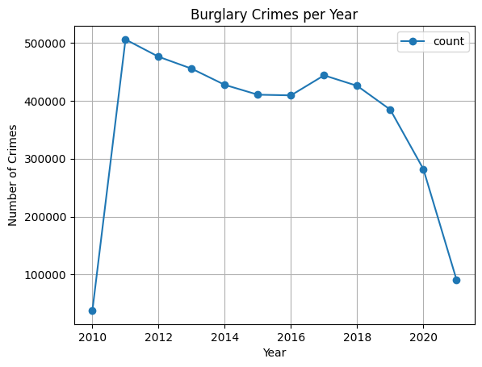

```python
# Buglary trend line chart
burglary_plot = Burglary_trend.toPandas()
burglary_plot.plot(x='Year', y='count', kind='line', marker='o')
plt.title("Burglary Crimes per Year")
plt.ylabel("Number of Crimes")
plt.grid(True)
plt.show()
```

**Conclusion:** Overall trend is decreasing after the peak in 2011. So the claim that “Burglary crime is continuously increasing” is false.

# **Firearms Incidents Assumptions:**

```python
# Firearms Assumptions
Firearms_Incident = (DF.dropna(subset=["Crime type", "LSOA name", "Last outcome category"])
                    .filter(col("Crime type") == "Possession of weapons")
                    .filter(col("Last outcome category") == "Offender sent to prison")
)
```

# **Firearms Incidents per Head:**

```python
# Firearms incedent by LASOA name
Firearms_by_LSOA_name = (
                    Firearms_Incident
                    .groupBy("LSOA name")
                    .count()
                    .withColumnRenamed("count", "Firearms_Incident")
)
```

```python
# Join the LSOA name with the LSOA population
Firearms_with_pop = Firearms_by_LSOA_name.join(LSOA_pop, Firearms_by_LSOA_name["LSOA name"] == LSOA_pop["geography"], \
                                               how="inner")
```

```python
# Firearms incidents per head
Firearms_with_pop = Firearms_with_pop.withColumn(
    "Incidents_per_head", col("Firearms_Incident") / col("Variable: All usual residents; measures: Value"))
```

```python
# Liverpool Firearms incidents per head
liverpool_Firearms = Firearms_with_pop.filter(col("LSOA name").like("%Liverpool%")) \
.select("LSOA name", "Firearms_Incident", "Variable: All usual residents; measures: Value", "Incidents_per_head")
```

```python
# Rename population column for readability and display Liverpool firearms table
liverpool_Firearms = liverpool_Firearms.withColumnRenamed(
    "Variable: All usual residents; measures: Value", "Population"
)
liverpool_Firearms.show(truncate=False)
```

```
+--------------+-----------------+----------+---------------------+
|LSOA name     |Firearms_Incident|Population|Incidents_per_head   |
+--------------+-----------------+----------+---------------------+
|Liverpool 044D|1                |1753      |5.704506560182544E-4 |
|Liverpool 062D|2                |1082      |0.0018484288354898336|
|Liverpool 023D|1                |2175      |4.597701149425287E-4 |
|Liverpool 012D|2                |1716      |0.0011655011655011655|
|Liverpool 060C|14               |2115      |0.006619385342789598 |
|Liverpool 005E|1                |1460      |6.849315068493151E-4 |
|Liverpool 030A|1                |1503      |6.653359946773121E-4 |
|Liverpool 060A|3                |2941      |0.0010200612036722204|
|Liverpool 005B|2                |1765      |0.0011331444759206798|
|Liverpool 020F|4                |1359      |0.0029433406916850625|
|Liverpool 009C|1                |1397      |7.158196134574087E-4 |
|Liverpool 030B|7                |1864      |0.0037553648068669528|
|Liverpool 027D|1                |1436      |6.963788300835655E-4 |
|Liverpool 055E|1                |1318      |7.587253414264037E-4 |
|Liverpool 026A|1                |1655      |6.042296072507553E-4 |
|Liverpool 005D|1                |1309      |7.639419404125286E-4 |
|Liverpool 028C|2                |1821      |0.001098297638660077 |
|Liverpool 004C|3                |1153      |0.0026019080659150044|
|Liverpool 035C|3                |1565      |0.0019169329073482429|
|Liverpool 035A|1                |2108      |4.743833017077799E-4 |
+--------------+-----------------+----------+---------------------+
only showing top 20 rows
```

# **Comparison between Liverpool and Anywhere else in the UK:**

```python
# Comparison beetween Firearms in Liverpool per head and anywhere in the UK
liverpool = Firearms_with_pop.filter(col("LSOA name").like("%Liverpool%"))
Anywhere_in_UK = Firearms_with_pop.filter(~col("LSOA name").like("%Liverpool%"))
```

```python
liverpool_max_firearm = liverpool.agg({"Incidents_per_head": "max"}).collect()[0][0]
print(f"Maximum firearm incidents per head in Liverpool: {liverpool_max_firearm}")
```

```
Maximum firearm incidents per head in Liverpool: 0.006619385342789598
```

```python
Anywhere_in_UK_max = Anywhere_in_UK.agg({"Incidents_per_head": "max"}).collect()[0][0]
print(f"Max incidents per head in rest of the UK: {Anywhere_in_UK_max}")
```

```
Max incidents per head in rest of the UK: 0.0196078431372549
```

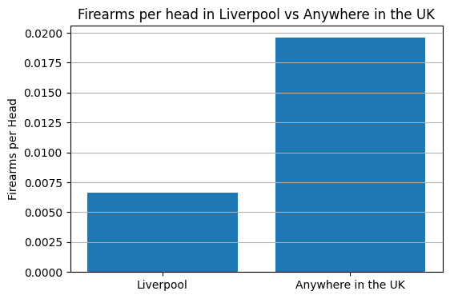

```python
# Comprison bar chart
labels = ["Liverpool", "Anywhere in the UK"]
values = [liverpool_max_firearm, Anywhere_in_UK_max]

plt.figure(figsize=(6,4))
plt.bar(labels, values)
plt.title("Firearms per head in Liverpool vs Anywhere in the UK")
plt.ylabel("Firearms per Head")
plt.grid(axis="y")
plt.show()
```

**Conclusion:** The claim that Liverpool has more firearms incidents per head than anywhere else in the UK is false. Although firearms offences occur in Liverpool, its highest per-capita rate (0.007) is lower than the maximum observed elsewhere in the UK (0.02), indicating higher relative firearm incidence in other areas once population size is considered.

# **Firearms and Drugs Association:**

```python
# Firearms and Drugs
Firearms = Filtered_Crimes.filter(col("Crime type") == "Possession of weapons") \
               .groupBy("LSOA name") \
               .count() \
               .withColumnRenamed("count", "Firearms")
```

```python
Drug = Filtered_Crimes.filter(col("Crime type") == "Drugs") \
               .groupBy("LSOA name") \
               .count() \
               .withColumnRenamed("count", "Drugs")
```

```python
# Pearson correlation
Firearms_Drug = Firearms.join(Drug, on = "LSOA name", how = "outer").fillna(0)
Firearms_Drug.stat.corr("Firearms", "Drugs")
```

```
0.021632406459882465
```

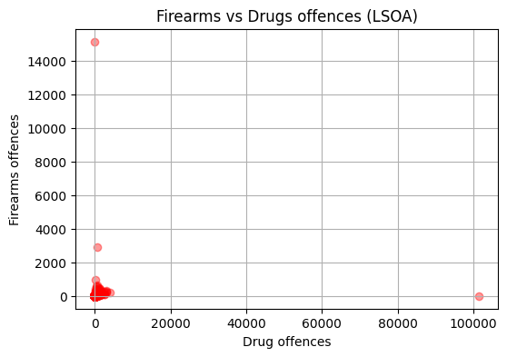

```python
# Firearms vs Drugs scatter plot
fd_plot = Firearms_Drug.toPandas()
plt.figure(figsize=(6,4))
plt.scatter(fd_plot["Drugs"], fd_plot["Firearms"], color="red", alpha = 0.4)
plt.title("Firearms vs Drugs offences (LSOA)")
plt.xlabel("Drug offences")
plt.ylabel("Firearms offences")
plt.grid(True)
plt.show()
```

**conclusion:** There is no close association between firearms and drug offences. Both the scatter plot and the near-zero correlation coefficient (0.02) show that firearm incidents are not strongly linked to drug-related crime at LSOA level. Therefore the claim is false.

# **Statistical Analysis and Evaluation Measures using linear regression (Burglary):**

```python
from pyspark.ml.feature import VectorAssembler
from pyspark.ml.regression import LinearRegression

# Ensure Year is numeric
Burglary_trend = Burglary_trend.withColumn("Year", col("Year").cast("int"))

# Assemble features
assembler = VectorAssembler(inputCols=["Year"], outputCol="features")
data = assembler.transform(Burglary_trend).select("features", "count")

# Train linear regression
lr = LinearRegression(featuresCol="features", labelCol="count")
model = lr.fit(data)

print("Slope:", model.coefficients[0])
print("R2:", model.summary.r2)
print("RMSE:", model.summary.rootMeanSquaredError)
print("MAE:", model.summary.meanAbsoluteError)
```

```
Slope: -7567.405594399054
R2: 0.03312205660618728
RMSE: 141140.47882502133
MAE: 107022.44580419983
```

##### **Conclusion**: A linear regression analysis indicates that burglary incidents have declined over time, with an average annual decrease of approximately 7,567 crimes. This contradicts claims that burglary is continuously increasing. However, time alone explains only a small proportion of the variation in burglary rates, suggesting that factors such as socio-economic conditions, policing strategies, and reporting behaviour play a significant role. As a result, the model is useful for identifying overall direction rather than for precise forecasting.

# **Evaluation, Conclusion, Insurance advice**

Burglary rates have declined over time rather than increasing. Liverpool does not have the highest firearm incidents per capita. Firearm and drug offences show no strong statistical relationship. From an insurance risk perspective, these findings highlight the importance of data-driven, per-capita analysis and localised assessment rather than reliance on national narratives. Insurers should adopt dynamic models that incorporate socio-economic and regional variables to more accurately estimate crime-related risk.